# Many ElasticNet Models for BLCA across layers

Monti Lab

March 28, 2025

# Get the output of the ML model (loop through all layer combinations)

```r
# Personalized Layer Combinations

#layer_combinations <- list(c("miRNA"))
#layer_combinations <- list(c("miRNA"),c("miRNA","RPPA"))
#layer_combinations <- list(c("miRNA"),c("RPPA"),c("RNASeq"),c("miRNA","RPPA"),c("miRNA","RNASeq"),c("RNASeq","RPPA"), c("miRNA","RPPA","RNAseq")) #w/o methylation
#layer_combinations <- list(c("miRNA"),c("RPPA"))
#layer_combinations <- list(c("methylation"),c("miRNA"),c("RPPA"),c("RNAseq"),c("miRNA","RPPA"),c("miRNA","RNAseq"),c("RNAseq","RPPA"), c("miRNA","RPPA","RNAseq"))
#layer_combinations <- list(c("miRNA"), c("RNAseq"), c("methylation"), c("miRNA","RNAseq"), c("miRNA","methylation"))

#The correct form of writing it is RNAseq, case sensitive

#Given a series of models, perform all possible combinations if enabled
layers <- c("miRNA", "RPPA", "RNAseq", "methylation")
# layers <- c("methylation", "RNAseq")
if (getting_combinations){
  layer_combinations <- unlist(lapply(1:length(layers), function(x) {
    combn(layers, x, simplify = FALSE)
  }), recursive = FALSE)
} else{ layer_combinations <- layers }

for (comb in layer_combinations){
  print(comb)
}
```

```
## [1] "miRNA"
## [1] "RPPA"
## [1] "RNAseq"
## [1] "methylation"
```

# Running Models for:

````r
#Initializing a coefficient empty list so to append after every run
coef_list <- list()
cancer_summary_table <- intializeSummaryTable()

# Iterate through all values in layer_combinations
for (comb in layer_combinations) {
  # Generate tab heading based on the combination
  #cat(paste("Model for", comb, "\n\n"))
  #combination <- comb
  cat("\n\n##", comb, "\n\n")

  # Run standardized model building
  existingExperimentList <- NULL
  iterationCount <- 3
  modelOutput <- standardizedModelBuilding(comb,
                                           cancerName = cancer_type,
                                           methodNames = c(model_type),
                                           splitSize = 1,
                                           seed = 43,
                                           significanceCutoff=significance_cutoff,
                                           iterationCount=iterationCount)
  if (is.null(modelOutput)) {
    print(paste0("Could not load experiment for: ", getCancerLayersPrefix(cancer_type, comb)))
    next
  }

  coef_df <- modelOutput$ModelBuilding$weights

  # Print summary statistics for non-zero coefficients
  non_zero_coef_df <- coef_df[coef_df$Weight != 0, ]
  zero_coef_df <- coef_df[coef_df$Weight == 0, ]
  cat(paste("\n\n There are", nrow(non_zero_coef_df), "features with non-zero weights in this model.\n\n"))
  cat(paste("There are", nrow(zero_coef_df), "features with zero weight in this model.\n\n"))
  # Ensure `comb` is always converted into a single string
  coef_list[[getCancerLayersPrefix(cancer_type, comb)]] <- coef_df


  # Calculate and display survival statistics
  cat("\n\n### Evaluating delta age on Survival(coxph)\n\n")
  stats <- getSurvivalStats(modelOutput$experimentList[[1]],
                            modelOutput$ModelBuilding$predicted)

  cat("\n\n#### Interaction Coxph Model\n\n")
  cox_summary_i <- capture.output(stats$interaction_summary)
  cat("```\n", paste(cox_summary_i, collapse = "\n"), "\n```\n")

  cat("\n\n#### Non Interaction Coxph Model\n\n")
  cox_summary_ni <- capture.output(stats$non_interaction_summary)
  cat("```\n", paste(cox_summary_ni, collapse = "\n"), "\n```\n")

  cat("\n\n#### Baseline Coxph Model\n\n")
  cox_summary_b <- capture.output(stats$baseline_summary)
  cat("```\n", paste(cox_summary_b, collapse = "\n"), "\n```\n")

  #Making summary tables df1 <- (model performance & coxph) & df2 <- (coefficients and model weight)
  cancer_summary_table <- rbind(cancer_summary_table, getSummaryTable(comb, modelOutput, stats, params=params))
}
````

## miRNA

[1] “Checking for existing imputed datasets…” [1] “Filtering for covariates…” [1] “Getting cleaned assay data…” [1] “Additional feature filtering…” [1] “Combining assays…” [1] “Encoding covariates…” [1] “Train test splitting…” [1] “Cross validating…” [1] “Training model…” [1] “ElasticNet” [1] “Predicting…” [1] “Training model…” [1] “ElasticNet” [1] “Predicting…” [1] “Training model…” [1] “ElasticNet” [1] “Predicting…”

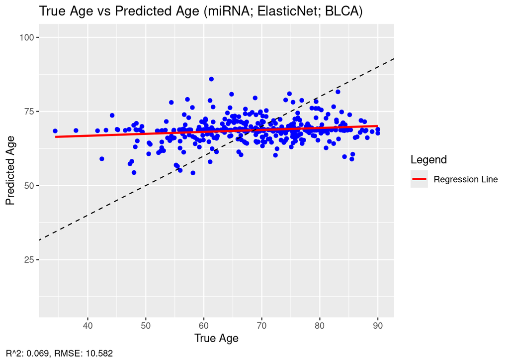

There are 150 features with non-zero weights in this model.

There are 305 features with zero weight in this model.

### Evaluating delta age on Survival(coxph)

#### Interaction Coxph Model

```
 Call:
coxph(formula = covariates_formula_interaction, data = experiment_prediction_object_meta)

  n= 407, number of events= 180

                                    coef  exp(coef)   se(coef)      z Pr(>|z|)
chronological                  0.0409244  1.0417733  0.0220111  1.859   0.0630
delta_age                      0.0235598  1.0238395  0.0536056  0.440   0.6603
gender.ymale                  -0.1051743  0.9001676  0.1659594 -0.634   0.5263
raceblack or african american  0.7470350  2.1107324  0.4360793  1.713   0.0867
racenot reported               0.1796050  1.1967445  0.5060895  0.355   0.7227
racewhite                      0.4276341  1.5336249  0.3463313  1.235   0.2169
chronological:delta_age       -0.0002662  0.9997339  0.0006927 -0.384   0.7008

chronological                 .
delta_age
gender.ymale
raceblack or african american .
racenot reported
racewhite
chronological:delta_age
---
Signif. codes:  0 '***' 0.001 '**' 0.01 '*' 0.05 '.' 0.1 ' ' 1

                              exp(coef) exp(-coef) lower .95 upper .95
chronological                    1.0418     0.9599    0.9978     1.088
delta_age                        1.0238     0.9767    0.9217     1.137
gender.ymale                     0.9002     1.1109    0.6502     1.246
raceblack or african american    2.1107     0.4738    0.8979     4.962
racenot reported                 1.1967     0.8356    0.4438     3.227
racewhite                        1.5336     0.6520    0.7779     3.024
chronological:delta_age          0.9997     1.0003    0.9984     1.001

Concordance= 0.619  (se = 0.022 )
Likelihood ratio test= 24.69  on 7 df,   p=9e-04
Wald test            = 23.35  on 7 df,   p=0.001
Score (logrank) test = 24.33  on 7 df,   p=0.001
```

#### Non Interaction Coxph Model

```
 Call:
coxph(formula = covariates_formula_non_interaction, data = experiment_prediction_object_meta)

  n= 407, number of events= 180

                                   coef exp(coef)  se(coef)      z Pr(>|z|)
chronological                  0.039857  1.040662  0.021816  1.827   0.0677 .
delta_age                      0.004531  1.004542  0.020453  0.222   0.8247
gender.ymale                  -0.105768  0.899633  0.165931 -0.637   0.5238
raceblack or african american  0.733503  2.082362  0.434605  1.688   0.0915 .
racenot reported               0.184697  1.202854  0.505934  0.365   0.7151
racewhite                      0.415095  1.514514  0.344589  1.205   0.2284
---
Signif. codes:  0 '***' 0.001 '**' 0.01 '*' 0.05 '.' 0.1 ' ' 1

                              exp(coef) exp(-coef) lower .95 upper .95
chronological                    1.0407     0.9609    0.9971     1.086
delta_age                        1.0045     0.9955    0.9651     1.046
gender.ymale                     0.8996     1.1116    0.6499     1.245
raceblack or african american    2.0824     0.4802    0.8884     4.881
racenot reported                 1.2029     0.8314    0.4462     3.242
racewhite                        1.5145     0.6603    0.7708     2.976

Concordance= 0.619  (se = 0.022 )
Likelihood ratio test= 24.54  on 6 df,   p=4e-04
Wald test            = 22.61  on 6 df,   p=9e-04
Score (logrank) test = 22.9  on 6 df,   p=8e-04
```

#### Baseline Coxph Model

```
 Call:
coxph(formula = covariates_formula_baseline, data = experiment_prediction_object_meta)

  n= 407, number of events= 180

                                   coef exp(coef)  se(coef)      z Pr(>|z|)
chronological                  0.035363  1.035996  0.008059  4.388 1.14e-05 ***
gender.ymale                  -0.106352  0.899108  0.165910 -0.641   0.5215
raceblack or african american  0.733770  2.082918  0.434584  1.688   0.0913 .
racenot reported               0.188857  1.207869  0.505562  0.374   0.7087
racewhite                      0.417029  1.517447  0.344466  1.211   0.2260
---
Signif. codes:  0 '***' 0.001 '**' 0.01 '*' 0.05 '.' 0.1 ' ' 1

                              exp(coef) exp(-coef) lower .95 upper .95
chronological                    1.0360     0.9653    1.0198     1.052
gender.ymale                     0.8991     1.1122    0.6495     1.245
raceblack or african american    2.0829     0.4801    0.8887     4.882
racenot reported                 1.2079     0.8279    0.4484     3.254
racewhite                        1.5174     0.6590    0.7725     2.981

Concordance= 0.618  (se = 0.022 )
Likelihood ratio test= 24.49  on 5 df,   p=2e-04
Wald test            = 22.56  on 5 df,   p=4e-04
Score (logrank) test = 22.86  on 5 df,   p=4e-04
```

## RPPA

[1] “Checking for existing imputed datasets…” [1] “Loading existing imputed dataset for RPPA ( BLCA ) from /restricted/projectnb/agedisease/projects/pancancer_aging_clocks/scripts/imputations_0.05/RPPA/TCGA-BLCA_RPPA_imputed.rds” [1] “Filtering for covariates…” [1] “Getting cleaned assay data…” [1] “Additional feature filtering…” [1] “Combining assays…” [1] “Encoding covariates…” [1] “Train test splitting…” [1] “Cross validating…” [1] “Training model…” [1] “ElasticNet” [1] “Predicting…” [1] “Training model…” [1] “ElasticNet” [1] “Predicting…” [1] “Training model…” [1] “ElasticNet” [1] “Predicting…”

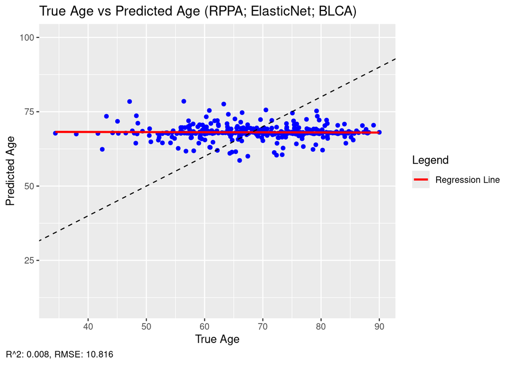

There are 55 features with non-zero weights in this model.

There are 405 features with zero weight in this model.

### Evaluating delta age on Survival(coxph)

#### Interaction Coxph Model

```
 Call:
coxph(formula = covariates_formula_interaction, data = experiment_prediction_object_meta)

  n= 341, number of events= 156

                                    coef  exp(coef)   se(coef)      z Pr(>|z|)
chronological                  0.0639600  1.0660497  0.0317801  2.013   0.0442
delta_age                      0.0344227  1.0350220  0.0635321  0.542   0.5879
gender.ymale                   0.0047426  1.0047539  0.1814710  0.026   0.9792
raceblack or african american  0.8189473  2.2681111  0.4534526  1.806   0.0709
racenot reported               0.0786127  1.0817852  0.5432971  0.145   0.8850
racewhite                      0.3648336  1.4402743  0.3674111  0.993   0.3207
chronological:delta_age       -0.0000999  0.9999001  0.0007694 -0.130   0.8967

chronological                 *
delta_age
gender.ymale
raceblack or african american .
racenot reported
racewhite
chronological:delta_age
---
Signif. codes:  0 '***' 0.001 '**' 0.01 '*' 0.05 '.' 0.1 ' ' 1

                              exp(coef) exp(-coef) lower .95 upper .95
chronological                    1.0660     0.9380    1.0017     1.135
delta_age                        1.0350     0.9662    0.9138     1.172
gender.ymale                     1.0048     0.9953    0.7040     1.434
raceblack or african american    2.2681     0.4409    0.9326     5.516
racenot reported                 1.0818     0.9244    0.3730     3.138
racewhite                        1.4403     0.6943    0.7010     2.959
chronological:delta_age          0.9999     1.0001    0.9984     1.001

Concordance= 0.623  (se = 0.024 )
Likelihood ratio test= 23.42  on 7 df,   p=0.001
Wald test            = 22.16  on 7 df,   p=0.002
Score (logrank) test = 23.05  on 7 df,   p=0.002
```

#### Non Interaction Coxph Model

```
 Call:
coxph(formula = covariates_formula_non_interaction, data = experiment_prediction_object_meta)

  n= 341, number of events= 156

                                  coef exp(coef) se(coef)     z Pr(>|z|)
chronological                 0.063616  1.065683 0.031656 2.010   0.0445 *
delta_age                     0.027256  1.027631 0.031409 0.868   0.3855
gender.ymale                  0.005651  1.005667 0.181324 0.031   0.9751
raceblack or african american 0.813740  2.256330 0.451616 1.802   0.0716 .
racenot reported              0.081253  1.084646 0.542874 0.150   0.8810
racewhite                     0.360994  1.434755 0.366115 0.986   0.3241
---
Signif. codes:  0 '***' 0.001 '**' 0.01 '*' 0.05 '.' 0.1 ' ' 1

                              exp(coef) exp(-coef) lower .95 upper .95
chronological                     1.066     0.9384    1.0016     1.134
delta_age                         1.028     0.9731    0.9663     1.093
gender.ymale                      1.006     0.9944    0.7049     1.435
raceblack or african american     2.256     0.4432    0.9311     5.468
racenot reported                  1.085     0.9220    0.3743     3.143
racewhite                         1.435     0.6970    0.7001     2.940

Concordance= 0.623  (se = 0.024 )
Likelihood ratio test= 23.4  on 6 df,   p=7e-04
Wald test            = 21.94  on 6 df,   p=0.001
Score (logrank) test = 22.2  on 6 df,   p=0.001
```

#### Baseline Coxph Model

```
 Call:
coxph(formula = covariates_formula_baseline, data = experiment_prediction_object_meta)

  n= 341, number of events= 156

                                   coef exp(coef)  se(coef)     z Pr(>|z|)
chronological                 0.0371516 1.0378504 0.0088124 4.216 2.49e-05 ***
gender.ymale                  0.0005999 1.0006001 0.1813318 0.003   0.9974
raceblack or african american 0.8361038 2.3073595 0.4508512 1.855   0.0637 .
racenot reported              0.0927915 1.0972329 0.5426974 0.171   0.8642
racewhite                     0.3680882 1.4449694 0.3659439 1.006   0.3145
---
Signif. codes:  0 '***' 0.001 '**' 0.01 '*' 0.05 '.' 0.1 ' ' 1

                              exp(coef) exp(-coef) lower .95 upper .95
chronological                     1.038     0.9635    1.0201     1.056
gender.ymale                      1.001     0.9994    0.7013     1.428
raceblack or african american     2.307     0.4334    0.9536     5.583
racenot reported                  1.097     0.9114    0.3788     3.179
racewhite                         1.445     0.6921    0.7053     2.960

Concordance= 0.616  (se = 0.024 )
Likelihood ratio test= 22.65  on 5 df,   p=4e-04
Wald test            = 20.95  on 5 df,   p=8e-04
Score (logrank) test = 21.23  on 5 df,   p=7e-04
```

## RNAseq

[1] “Checking for existing imputed datasets…” [1] “Loading existing imputed dataset for RNAseq ( BLCA ) from /restricted/projectnb/agedisease/projects/pancancer_aging_clocks/scripts/imputations_0.05/RNAseq/TCGA-BLCA_RNAseq_imputed.rds” [1] “Filtering for covariates…” [1] “Getting cleaned assay data…” [1] “Additional feature filtering…” [1] “Combining assays…” [1] “Encoding covariates…” [1] “Train test splitting…” [1] “Cross validating…” [1] “Training model…” [1] “ElasticNet” [1] “Predicting…” [1] “Training model…” [1] “ElasticNet” [1] “Predicting…” [1] “Training model…” [1] “ElasticNet” [1] “Predicting…”

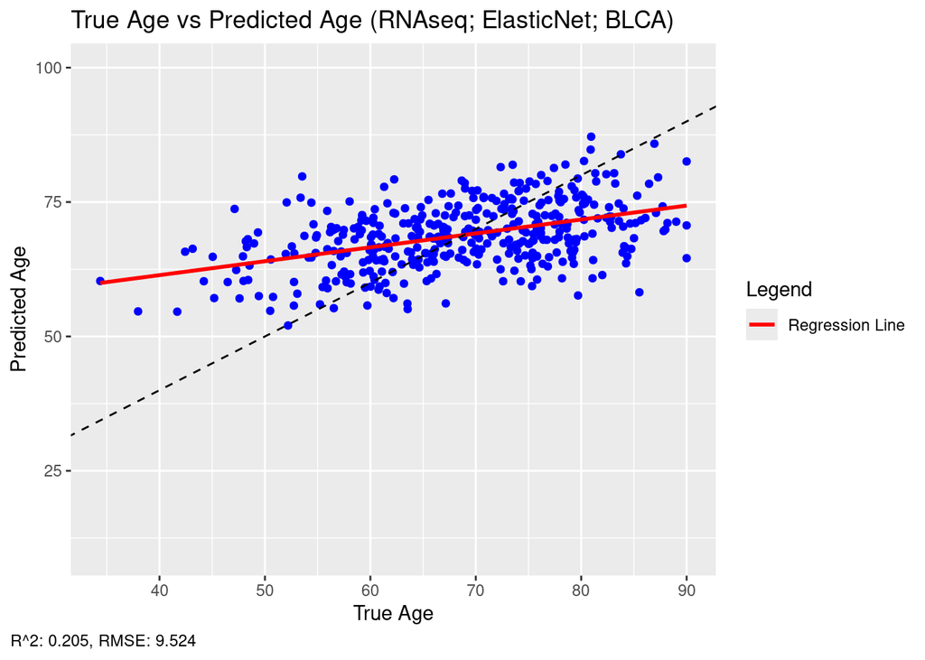

There are 272 features with non-zero weights in this model.

There are 559 features with zero weight in this model.

### Evaluating delta age on Survival(coxph)

#### Interaction Coxph Model

```
 Call:
coxph(formula = covariates_formula_interaction, data = experiment_prediction_object_meta)

  n= 404, number of events= 179

                                    coef  exp(coef)   se(coef)      z Pr(>|z|)
chronological                  0.0426116  1.0435326  0.0153882  2.769  0.00562
delta_age                     -0.0405646  0.9602471  0.0524009 -0.774  0.43886
gender.ymale                  -0.0844267  0.9190390  0.1677275 -0.503  0.61471
raceblack or african american  0.6896425  1.9930029  0.4365634  1.580  0.11417
racenot reported               0.3479883  1.4162157  0.5105916  0.682  0.49553
racewhite                      0.3547653  1.4258460  0.3495703  1.015  0.31017
chronological:delta_age        0.0006853  1.0006856  0.0007199  0.952  0.34113

chronological                 **
delta_age
gender.ymale
raceblack or african american
racenot reported
racewhite
chronological:delta_age
---
Signif. codes:  0 '***' 0.001 '**' 0.01 '*' 0.05 '.' 0.1 ' ' 1

                              exp(coef) exp(-coef) lower .95 upper .95
chronological                    1.0435     0.9583    1.0125     1.075
delta_age                        0.9602     1.0414    0.8665     1.064
gender.ymale                     0.9190     1.0881    0.6616     1.277
raceblack or african american    1.9930     0.5018    0.8470     4.689
racenot reported                 1.4162     0.7061    0.5206     3.853
racewhite                        1.4258     0.7013    0.7187     2.829
chronological:delta_age          1.0007     0.9993    0.9993     1.002

Concordance= 0.624  (se = 0.022 )
Likelihood ratio test= 26.93  on 7 df,   p=3e-04
Wald test            = 23.32  on 7 df,   p=0.002
Score (logrank) test = 24.3  on 7 df,   p=0.001
```

#### Non Interaction Coxph Model

```
 Call:
coxph(formula = covariates_formula_non_interaction, data = experiment_prediction_object_meta)

  n= 404, number of events= 179

                                  coef exp(coef) se(coef)      z Pr(>|z|)
chronological                  0.04477   1.04579  0.01526  2.933  0.00335 **
delta_age                      0.00787   1.00790  0.01254  0.628  0.53011
gender.ymale                  -0.07993   0.92318  0.16784 -0.476  0.63391
raceblack or african american  0.72968   2.07441  0.43461  1.679  0.09317 .
racenot reported               0.30873   1.36169  0.50864  0.607  0.54387
racewhite                      0.38209   1.46535  0.34882  1.095  0.27335
---
Signif. codes:  0 '***' 0.001 '**' 0.01 '*' 0.05 '.' 0.1 ' ' 1

                              exp(coef) exp(-coef) lower .95 upper .95
chronological                    1.0458     0.9562    1.0150     1.078
delta_age                        1.0079     0.9922    0.9834     1.033
gender.ymale                     0.9232     1.0832    0.6644     1.283
raceblack or african american    2.0744     0.4821    0.8850     4.862
racenot reported                 1.3617     0.7344    0.5025     3.690
racewhite                        1.4653     0.6824    0.7396     2.903

Concordance= 0.62  (se = 0.022 )
Likelihood ratio test= 25.99  on 6 df,   p=2e-04
Wald test            = 24  on 6 df,   p=5e-04
Score (logrank) test = 24.3  on 6 df,   p=5e-04
```

#### Baseline Coxph Model

```
 Call:
coxph(formula = covariates_formula_baseline, data = experiment_prediction_object_meta)

  n= 404, number of events= 179

                                   coef exp(coef)  se(coef)      z Pr(>|z|)
chronological                  0.036622  1.037301  0.008064  4.541 5.59e-06 ***
gender.ymale                  -0.075628  0.927161  0.167607 -0.451   0.6518
raceblack or african american  0.733601  2.082567  0.434549  1.688   0.0914 .
racenot reported               0.342284  1.408160  0.505592  0.677   0.4984
racewhite                      0.416108  1.516049  0.344570  1.208   0.2272
---
Signif. codes:  0 '***' 0.001 '**' 0.01 '*' 0.05 '.' 0.1 ' ' 1

                              exp(coef) exp(-coef) lower .95 upper .95
chronological                    1.0373     0.9640    1.0210     1.054
gender.ymale                     0.9272     1.0786    0.6676     1.288
raceblack or african american    2.0826     0.4802    0.8886     4.881
racenot reported                 1.4082     0.7101    0.5227     3.793
racewhite                        1.5160     0.6596    0.7716     2.979

Concordance= 0.62  (se = 0.022 )
Likelihood ratio test= 25.59  on 5 df,   p=1e-04
Wald test            = 23.55  on 5 df,   p=3e-04
Score (logrank) test = 23.89  on 5 df,   p=2e-04
```

## methylation

[1] “Checking for existing imputed datasets…” [1] “Loading existing imputed dataset for methylation ( BLCA ) from /restricted/projectnb/agedisease/projects/pancancer_aging_clocks/scripts/imputations_0.05/methylation/TCGA-BLCA_methylation_imputed.rds” [1] “Filtering for covariates…” [1] “Getting cleaned assay data…” [1] “Additional feature filtering…” [1] “Combining assays…” [1] “Encoding covariates…” [1] “Train test splitting…” [1] “Cross validating…” [1] “Training model…” [1] “ElasticNet” [1] “Predicting…” [1] “Training model…” [1] “ElasticNet” [1] “Predicting…” [1] “Training model…” [1] “ElasticNet” [1] “Predicting…”

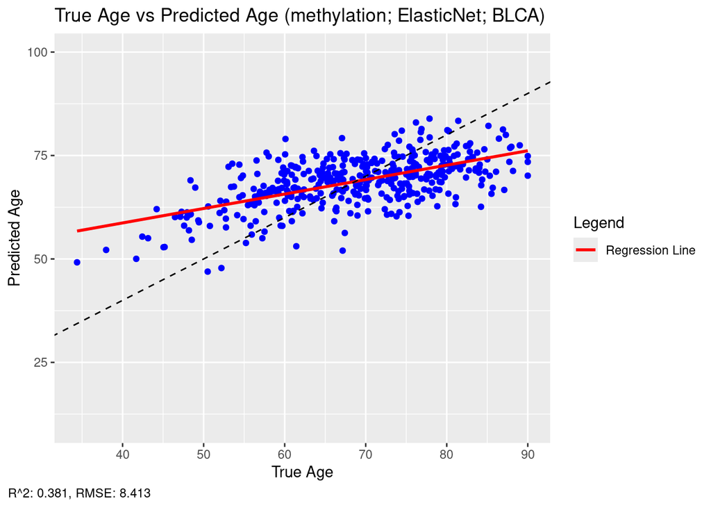

There are 168 features with non-zero weights in this model.

There are 677 features with zero weight in this model.

### Evaluating delta age on Survival(coxph)

#### Interaction Coxph Model

```
 Call:
coxph(formula = covariates_formula_interaction, data = experiment_prediction_object_meta)

  n= 410, number of events= 182

                                    coef  exp(coef)   se(coef)      z Pr(>|z|)
chronological                  0.0623628  1.0643484  0.0160027  3.897 9.74e-05
delta_age                     -0.0027806  0.9972233  0.0507601 -0.055   0.9563
gender.ymale                  -0.1083693  0.8972962  0.1659517 -0.653   0.5137
raceblack or african american  0.8058118  2.2385131  0.4395213  1.833   0.0667
racenot reported               0.2502585  1.2843573  0.5064687  0.494   0.6212
racewhite                      0.4630772  1.5889559  0.3460053  1.338   0.1808
chronological:delta_age        0.0004340  1.0004341  0.0006816  0.637   0.5243

chronological                 ***
delta_age
gender.ymale
raceblack or african american .
racenot reported
racewhite
chronological:delta_age
---
Signif. codes:  0 '***' 0.001 '**' 0.01 '*' 0.05 '.' 0.1 ' ' 1

                              exp(coef) exp(-coef) lower .95 upper .95
chronological                    1.0643     0.9395    1.0315     1.098
delta_age                        0.9972     1.0028    0.9028     1.102
gender.ymale                     0.8973     1.1145    0.6482     1.242
raceblack or african american    2.2385     0.4467    0.9459     5.298
racenot reported                 1.2844     0.7786    0.4760     3.466
racewhite                        1.5890     0.6293    0.8065     3.131
chronological:delta_age          1.0004     0.9996    0.9991     1.002

Concordance= 0.622  (se = 0.023 )
Likelihood ratio test= 29.17  on 7 df,   p=1e-04
Wald test            = 26.12  on 7 df,   p=5e-04
Score (logrank) test = 26.74  on 7 df,   p=4e-04
```

#### Non Interaction Coxph Model

```
 Call:
coxph(formula = covariates_formula_non_interaction, data = experiment_prediction_object_meta)

  n= 410, number of events= 182

                                  coef exp(coef) se(coef)      z Pr(>|z|)
chronological                  0.06432   1.06643  0.01580  4.070 4.69e-05 ***
delta_age                      0.02850   1.02891  0.01309  2.178   0.0294 *
gender.ymale                  -0.10996   0.89587  0.16596 -0.663   0.5076
raceblack or african american  0.83410   2.30274  0.43730  1.907   0.0565 .
racenot reported               0.23617   1.26639  0.50600  0.467   0.6407
racewhite                      0.47914   1.61468  0.34524  1.388   0.1652
---
Signif. codes:  0 '***' 0.001 '**' 0.01 '*' 0.05 '.' 0.1 ' ' 1

                              exp(coef) exp(-coef) lower .95 upper .95
chronological                    1.0664     0.9377    1.0339     1.100
delta_age                        1.0289     0.9719    1.0029     1.056
gender.ymale                     0.8959     1.1162    0.6471     1.240
raceblack or african american    2.3027     0.4343    0.9773     5.426
racenot reported                 1.2664     0.7896    0.4697     3.414
racewhite                        1.6147     0.6193    0.8208     3.177

Concordance= 0.62  (se = 0.023 )
Likelihood ratio test= 28.76  on 6 df,   p=7e-05
Wald test            = 26.51  on 6 df,   p=2e-04
Score (logrank) test = 26.74  on 6 df,   p=2e-04
```

#### Baseline Coxph Model

```
 Call:
coxph(formula = covariates_formula_baseline, data = experiment_prediction_object_meta)

  n= 410, number of events= 182

                                   coef exp(coef)  se(coef)      z Pr(>|z|)
chronological                  0.034726  1.035336  0.008004  4.339 1.43e-05 ***
gender.ymale                  -0.086122  0.917483  0.165519 -0.520   0.6028
raceblack or african american  0.734008  2.083414  0.434538  1.689   0.0912 .
racenot reported               0.194758  1.215017  0.505609  0.385   0.7001
racewhite                      0.426598  1.532037  0.344313  1.239   0.2154
---
Signif. codes:  0 '***' 0.001 '**' 0.01 '*' 0.05 '.' 0.1 ' ' 1

                              exp(coef) exp(-coef) lower .95 upper .95
chronological                    1.0353     0.9659    1.0192     1.052
gender.ymale                     0.9175     1.0899    0.6633     1.269
raceblack or african american    2.0834     0.4800    0.8890     4.883
racenot reported                 1.2150     0.8230    0.4510     3.273
racewhite                        1.5320     0.6527    0.7802     3.008

Concordance= 0.616  (se = 0.022 )
Likelihood ratio test= 23.94  on 5 df,   p=2e-04
Wald test            = 22.05  on 5 df,   p=5e-04
Score (logrank) test = 22.33  on 5 df,   p=5e-04
```

## Model Weights

```r
#searchable = true

cat("\n\n# Model Weights\n\n")
```

# Model Weights

```r
# Create a list of HTML tags, each containing a header + reactable
# all_tables <- lapply(names(coef_list), function(placeholder) {
#   div(
#     h3(placeholder),
#     reactable(coef_list[[placeholder]], searchable = TRUE)
#   )
# })
#taglist(all_tables)


all_tables <- lapply(names(coef_list), function(placeholder) {
  div(
    h3(placeholder),
    reactable(
      coef_list[[placeholder]] %>%
        mutate(across(where(~is.numeric(.) && any(. %% 1 != 0, na.rm = TRUE)),
                      ~signif(., digits = 3))),
      searchable = TRUE
    )
  )
})

tagList(all_tables)
```

### BLCA_miRNA

| Feature | Weight |
| --- | --- |
| genderfemale | 0.36 |
| gendermale | -0.359 |
| raceblack.or.african.american | 0 |
| racenot.reported | 0 |
| racewhite | 0.642 |
| hsa-let-7a-1 | 0 |
| hsa-let-7a-2 | 0 |
| hsa-let-7a-3 | 0 |
| hsa-let-7b | 0 |
| hsa-let-7c | 0 |

[output cut: 445 more lines]

### BLCA_RPPA

| Feature | Weight |
| --- | --- |
| genderfemale | 0.235 |
| gendermale | -0.226 |
| raceblack.or.african.american | 0 |
| racenot.reported | 0 |
| racewhite | 0.95 |
| 4EBP1 | 0 |
| 4EBP1_pS65 | 0 |
| 4EBP1_pT37T46 | -0.522 |
| ACC_pS79 | 0 |
| ACC1 | 0 |

[output cut: 450 more lines]

### BLCA_RNAseq

| Feature | Weight |
| --- | --- |
| genderfemale | 1.25 |
| gendermale | -0.622 |
| raceblack.or.african.american | 0 |
| racenot.reported | -0.935 |
| racewhite | 0.673 |
| ENSG00000003400.15 | 0 |
| ENSG00000004142.12 | 0 |
| ENSG00000004478.8 | 0.801 |
| ENSG00000006625.18 | 0.135 |
| ENSG00000007255.10 | 0 |

[output cut: 821 more lines]

### BLCA_methylation

| Feature | Weight |
| --- | --- |
| genderfemale | 0.945 |
| gendermale | -0.877 |
| raceblack.or.african.american | 0 |
| racenot.reported | 0 |
| racewhite | 0 |
| cg05663064 | 0 |
| cg14911690 | 1.86 |
| cg21401879 | 0.106 |
| cg06168026 | 0.00371 |
| cg24741066 | 0 |

[output cut: 835 more lines]